# Predict survival on the Titanic

Jin Yong Kim

2 November 2017

## Predict survival on the Titanic

### Introduction

This is my first project that is uploaded on github so there should be much better way to predict the survivors. As for this time, I will use RandomForest to make Machine Learning model and predict test data set.

### Preparation

##### Initial works

```r
#Load packages
library(mice)
library(dplyr)
library(randomForest)
library(caret)
#Set up Working directory
setwd('c:/Kaggle/titanic')  #Location where I saved train.csv and test.csv files
```

We need to combine train.csv and test.csv files in order to fill up the missing values. I will change brank cells to NAs as it is easier to fill up the missing values.

```r
#Combine train.csv and test.csv files
train <- read.csv('train.csv', na.strings = c("", "NA"), stringsAsFactors = F)
test <- read.csv('test.csv', na.strings = c("", "NA"), stringsAsFactors = F)
total <- bind_rows(train, test)
```

##### Adding new column

```r
#make Title column
total$Title <- gsub('(.*, )|(\\..*)', '', total$Name)
total$Title[total$Title == 'Mlle'] <- 'Miss'
total$Title[total$Title == 'Ms'] <- 'Miss'
total$Title[total$Title == 'Mme'] <- 'Mrs'
```

```r
#check title counts by sex
table(total$Sex, total$Title)
```

```
##
##          Capt Col Don Dona  Dr Jonkheer Lady Major Master Miss  Mr Mrs Rev
##   female    0   0   0    1   1        0    1     0      0  264   0 198   0
##   male      1   4   1    0   7        1    0     2     61    0 757   0   8
##
##          Sir the Countess
##   female   0            1
##   male     1            0
```

Now, I am going to make Family size column and Deck column.

```r
#make family size column that contains the passenger themselves
total$FamilySize <- total$SibSp + total$Parch + 1
#make Deck column
total$Deck <- factor(sapply(total$Cabin, function(x) strsplit(x, NULL)[[1]][1]))
```

##### Exploratory analysis

I will used Tableau for visualise our data. First of all, I will see the relationship between sex and survived.

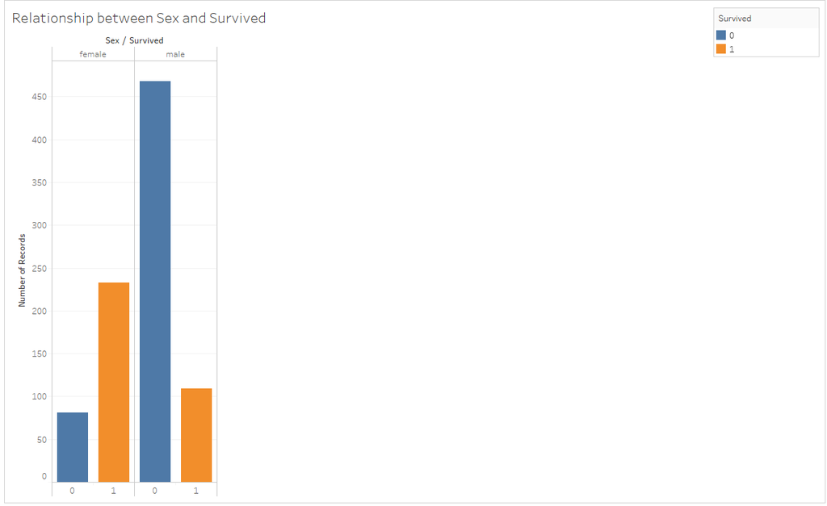

As we expected, the proportion of survived female was much higher than that of male.

What does our family size variable look like? To help us understand how it may relate to survival, I will also use Tableau and plot it.

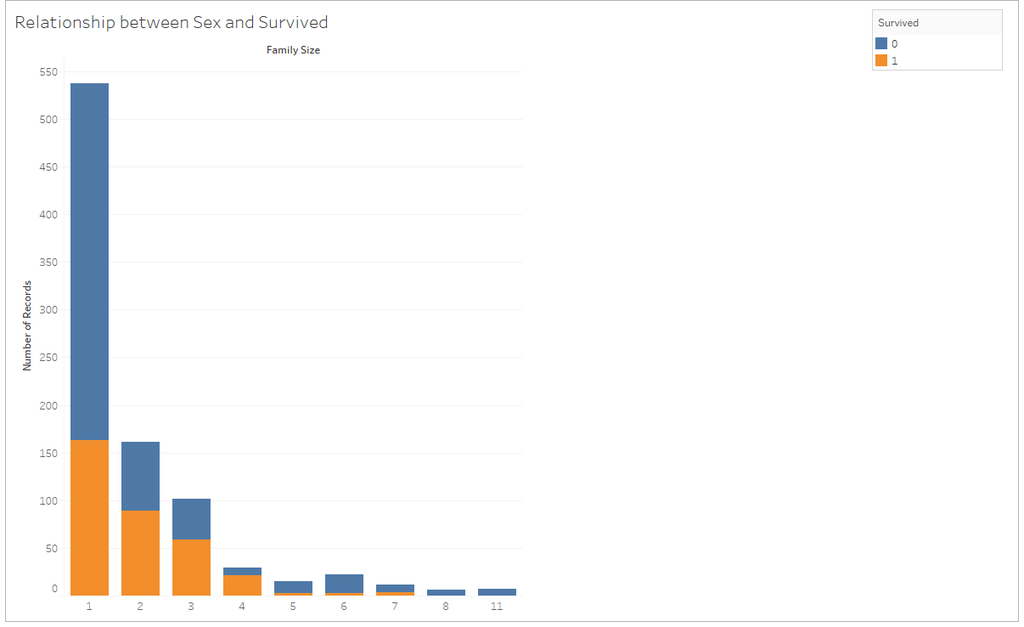

We can see that there’s a survival penalty to singletons and those with family sizes above 4. We can collapse this variable into three levels which will be helpful since there are comparatively fewer large families.

##### Filling up missing values

Before imputation, I will remove some variables and change categorical to factors.

```r
total1 <- total[,-c(1,2,4,9,11)]
total1 <- as.data.frame(unclass(total1))
```

I will impute missing values by using Mice package.

```r
#imputing missing values
miceMod <- mice(total1, method="rf")
miceOutput <- complete(miceMod)
#Check whether there is missing values
colnames(miceOutput)[colSums(is.na(miceOutput)) > 0]
```

```
## character(0)
```

##### Separation

I will separate back to train and test for prediction.

```r
#separate
train1 <- miceOutput[1:891,]
test1 <- miceOutput[892:1309,]
```

### Prediction

I will devide train set to training and testing to check accuracy.

```r
#add Survived column to train1
Survived <- train$Survived
train1 <- cbind(train1,Survived)
train1$Survived <- as.factor(train1$Survived)
```

```r
#split train
set.seed(54321)
outcome <- train1$Survived

partition <- createDataPartition(y=outcome,
                                 p=.7,
                                 list=F)
training <- train1[partition,]
testing <- train1[-partition,]
```

I will use simple Random Forest model to predict testing and check accuracy of a model.

```r
#predict with Random Forest
model_1 <- randomForest(Survived ~ ., data=training)
prediction <- predict(model_1, testing)
```

```r
confusionMatrix(prediction, testing$Survived)
```

```
## Confusion Matrix and Statistics
##
##           Reference
## Prediction   0   1
##          0 149  28
##          1  15  74
##
##                Accuracy : 0.8383
##                  95% CI : (0.7885, 0.8805)
##     No Information Rate : 0.6165
##     P-Value [Acc > NIR] : 2.231e-15
##
##                   Kappa : 0.6497
##  Mcnemar's Test P-Value : 0.06725
##
##             Sensitivity : 0.9085
##             Specificity : 0.7255
##          Pos Pred Value : 0.8418
##          Neg Pred Value : 0.8315
##              Prevalence : 0.6165
##          Detection Rate : 0.5602
##    Detection Prevalence : 0.6654
##       Balanced Accuracy : 0.8170
##
##        'Positive' Class : 0
##
```

```r
#predict, save and submit
prediction <- predict(model_1, test1)
solution <- data.frame(PassengerId = test$PassengerId, Survived = prediction)
write.csv(solution, file = 'randomforest_Sol.csv', row.names = F)
```